# modeling_mental_2014

### Mental Health in Survey 2014

In this notebook, I take the cleaned dataset and perform feature engineering.

To reduce the number of features, I'm replacing the following featutres: 'benefits', 'anonymity', 'wellness_program', 'seek_help', with "compnay support score".

Reducing the number of features improves analysis and model's performance, and reduce computational costs.

To determine if features correlate, I will be converting the features into integers (0 for no, and 1 for yes).

```python
import numpy as np
import pandas as pd
import matplotlib.pyplot as plt
import seaborn as sns
```

```python
df = pd.read_csv('cleaned_mental.csv')
```

```python
df.head()
```

|  | family_history | treatment | no_employees | tech_company | benefits | wellness_program | seek_help | anonymity | leave | mental_health_consequence | phys_health_consequence | coworkers | supervisor | mental_health_interview | phys_health_interview | mental_vs_physical | obs_consequence | support_score |
| --- | --- | --- | --- | --- | --- | --- | --- | --- | --- | --- | --- | --- | --- | --- | --- | --- | --- | --- |
| 0 | No | Yes | 6-25 | Yes | Yes | No | Yes | Yes | Somewhat easy | No | No | Some of them | Yes | No | Maybe | Yes | No | 3 |
| 1 | No | No | 1000-1100 | No | Don't know | Don't know | Don't know | Don't know | Don't know | Maybe | No | No | No | No | No | Don't know | No | 0 |
| 2 | No | No | 6-25 | Yes | No | No | No | Don't know | Somewhat difficult | No | No | Yes | Yes | Yes | Yes | No | No | 0 |
| 3 | Yes | Yes | 26-100 | Yes | No | No | No | No | Somewhat difficult | Yes | Yes | Some of them | No | Maybe | Maybe | No | Yes | 0 |
| 4 | No | No | 100-500 | Yes | Yes | Don't know | Don't know | Don't know | Don't know | No | No | Some of them | Yes | Yes | Yes | Don't know | No | 1 |

```python
df.isnull().sum()
```

[output not shown]

```python
df['no_employees'].info()
```

```
<class 'pandas.core.series.Series'>
RangeIndex: 1203 entries, 0 to 1202
Series name: no_employees
Non-Null Count  Dtype
--------------  -----
1203 non-null   object
dtypes: object(1)
memory usage: 9.5+ KB
```

Create company size column  
Company size can be infered from the number of employees.  
First, we need to convert the range in 'no_employees' column to midpoints (numerical values).  
Then, we define ordered categorical list.  
Lastly, we convert convert the column to categorical

```python
df['no_employees'].value_counts()
```

```
no_employees
6-25         277
26-100       274
1000-1100    272
100-500      168
1-5          154
500-1000      58
Name: count, dtype: int64
```

```python
#df['no_employees']=df['no_employees'].replace('1001', '1001-1300')
```

```python
df['no_employees'].value_counts()
```

[output not shown]

```python
def get_midpoint(range_str):
    start, end = map(int, range_str.split('-'))
    return (start+end)/2
```

```python
df['midpoint'] = df['no_employees'].apply(get_midpoint)
```

```python
df['midpoint'].value_counts()
```

```
midpoint
15.5      277
63.0      274
1050.0    272
300.0     168
3.0       154
750.0      58
Name: count, dtype: int64
```

```python
bins =[3, 15.5, 63.0, 300.0, 750.0, 1050.5]
labels = ['Micro', 'Small', 'Medium', 'Large', 'Enterprise']
```

```python
df['Company_Size'] = pd.cut(df['midpoint'], bins=bins, labels = labels, right=False)
```

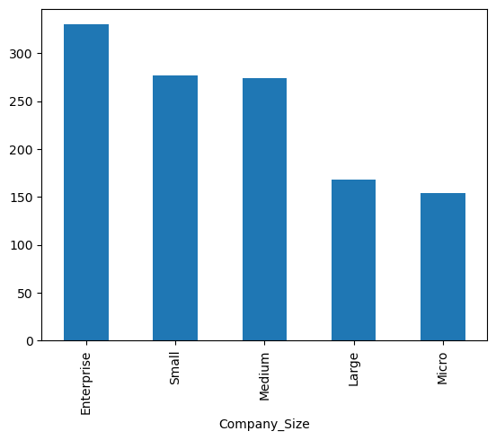

```python
df['Company_Size'].value_counts().plot(kind='bar')
```

```python
size_treatment= df.groupby('Company_Size')['treatment'].value_counts(normalize=True).unstack()

plt.figure(figsize=(10,8))

size_treatment.plot(kind='bar', stacked=False);
```

[output not shown]

```python
size_support = df.groupby('Company_Size')['support_score'].value_counts(normalize=True).unstack()
#company_size
# Plot the data
plt.figure(figsize=(10,8))
size_support.plot(kind='bar', stacked=False, edgecolor='black')
plt.title('Company Size and Support Score')
plt.xlabel('Company Size')
plt.ylabel('Proportion')
plt.legend(title='Support Score')
plt.xticks(rotation=45)
plt.tight_layout()
plt.show()
```

[output not shown]

#### Company Size and Mental Health

```python
#convert to ordered categories
df['Company_Size'] = pd.Categorical(df['Company_Size'], categories= labels, ordered = True)
```

```python
df.columns
```

```
Index(['family_history', 'treatment', 'no_employees', 'tech_company',
       'benefits', 'wellness_program', 'seek_help', 'anonymity', 'leave',
       'mental_health_consequence', 'phys_health_consequence', 'coworkers',
       'supervisor', 'mental_health_interview', 'phys_health_interview',
       'mental_vs_physical', 'obs_consequence', 'support_score', 'midpoint',
       'Company_Size'],
      dtype='object')
```

## Preprocessing

To look at correlation map, I'm going to convert the values of the featurse to integers.

1. Binary features

```python
bf = ['family_history', 'treatment', 'tech_company', 'obs_consequence']
mf = ['benefits', 'wellness_program', 'seek_help', 'anonymity', 'leave',
       'mental_health_consequence', 'phys_health_consequence', 'coworkers',
       'supervisor', 'mental_health_interview', 'phys_health_interview',
       'mental_vs_physical','Company_Size']
```

```python
for feature in bf:
    df[feature] = df[feature].map({'Yes': 1, 'No': 0})
```

```python
df.head()
```

|  | family_history | treatment | no_employees | tech_company | benefits | wellness_program | seek_help | anonymity | leave | mental_health_consequence | phys_health_consequence | coworkers | supervisor | mental_health_interview | phys_health_interview | mental_vs_physical | obs_consequence | support_score | midpoint | Company_Size |
| --- | --- | --- | --- | --- | --- | --- | --- | --- | --- | --- | --- | --- | --- | --- | --- | --- | --- | --- | --- | --- |
| 0 | 0 | 1 | 6-25 | 1 | Yes | No | Yes | Yes | Somewhat easy | No | No | Some of them | Yes | No | Maybe | Yes | 0 | 3 | 15.5 | Small |
| 1 | 0 | 0 | 1000-1100 | 0 | Don't know | Don't know | Don't know | Don't know | Don't know | Maybe | No | No | No | No | No | Don't know | 0 | 0 | 1050.0 | Enterprise |
| 2 | 0 | 0 | 6-25 | 1 | No | No | No | Don't know | Somewhat difficult | No | No | Yes | Yes | Yes | Yes | No | 0 | 0 | 15.5 | Small |
| 3 | 1 | 1 | 26-100 | 1 | No | No | No | No | Somewhat difficult | Yes | Yes | Some of them | No | Maybe | Maybe | No | 1 | 0 | 63.0 | Medium |
| 4 | 0 | 0 | 100-500 | 1 | Yes | Don't know | Don't know | Don't know | Don't know | No | No | Some of them | Yes | Yes | Yes | Don't know | 0 | 1 | 300.0 | Large |

```python
df = pd.get_dummies(df, columns =mf, drop_first=True)
```

```python
df.head()
```

|  | family_history | treatment | no_employees | tech_company | obs_consequence | support_score | midpoint | benefits_No | benefits_Yes | wellness_program_No | ... | mental_health_interview_No | mental_health_interview_Yes | phys_health_interview_No | phys_health_interview_Yes | mental_vs_physical_No | mental_vs_physical_Yes | Company_Size_Small | Company_Size_Medium | Company_Size_Large | Company_Size_Enterprise |
| --- | --- | --- | --- | --- | --- | --- | --- | --- | --- | --- | --- | --- | --- | --- | --- | --- | --- | --- | --- | --- | --- |
| 0 | 0 | 1 | 6-25 | 1 | 0 | 3 | 15.5 | False | True | True | ... | True | False | False | False | False | True | True | False | False | False |
| 1 | 0 | 0 | 1000-1100 | 0 | 0 | 0 | 1050.0 | False | False | False | ... | True | False | True | False | False | False | False | False | False | True |
| 2 | 0 | 0 | 6-25 | 1 | 0 | 0 | 15.5 | True | False | True | ... | False | True | False | True | True | False | True | False | False | False |
| 3 | 1 | 1 | 26-100 | 1 | 1 | 0 | 63.0 | True | False | True | ... | False | False | False | False | True | False | False | True | False | False |
| 4 | 0 | 0 | 100-500 | 1 | 0 | 1 | 300.0 | False | True | False | ... | False | True | False | True | False | False | False | False | True | False |

5 rows × 37 columns

```python
df.columns
```

```
Index(['family_history', 'treatment', 'no_employees', 'tech_company',
       'obs_consequence', 'support_score', 'midpoint', 'benefits_No',
       'benefits_Yes', 'wellness_program_No', 'wellness_program_Yes',
       'seek_help_No', 'seek_help_Yes', 'anonymity_No', 'anonymity_Yes',
       'leave_Somewhat difficult', 'leave_Somewhat easy',
       'leave_Very difficult', 'leave_Very easy',
       'mental_health_consequence_No', 'mental_health_consequence_Yes',
       'phys_health_consequence_No', 'phys_health_consequence_Yes',
       'coworkers_Some of them', 'coworkers_Yes', 'supervisor_Some of them',
       'supervisor_Yes', 'mental_health_interview_No',
       'mental_health_interview_Yes', 'phys_health_interview_No',
       'phys_health_interview_Yes', 'mental_vs_physical_No',
       'mental_vs_physical_Yes', 'Company_Size_Small', 'Company_Size_Medium',
       'Company_Size_Large', 'Company_Size_Enterprise'],
      dtype='object')
```

```python
new_df = df[['family_history', 'tech_company',
       'obs_consequence', 'support_score', 'benefits_No',
       'benefits_Yes', 'wellness_program_No', 'wellness_program_Yes',
       'seek_help_No', 'seek_help_Yes', 'anonymity_No', 'anonymity_Yes',
       'leave_Somewhat difficult', 'leave_Somewhat easy',
       'leave_Very difficult', 'leave_Very easy',
       'mental_health_consequence_No', 'mental_health_consequence_Yes',
       'phys_health_consequence_No', 'phys_health_consequence_Yes',
       'coworkers_Some of them', 'coworkers_Yes', 'supervisor_Some of them',
       'supervisor_Yes', 'mental_health_interview_No',
       'mental_health_interview_Yes', 'phys_health_interview_No',
       'phys_health_interview_Yes', 'mental_vs_physical_No',
       'mental_vs_physical_Yes', 'Company_Size_Small', 'Company_Size_Medium',
       'Company_Size_Large', 'Company_Size_Enterprise']]
```

```python
df2 = df[['family_history','treatment', 'tech_company', 'obs_consequence', 'support_score', 'coworkers_Some of them', 'coworkers_Yes', 'supervisor_Some of them',
       'supervisor_Yes',  'Company_Size_Small', 'Company_Size_Medium',
       'Company_Size_Large', 'Company_Size_Enterprise']]
```

```python
Y = df['treatment']
```

```python
new_df.shape, Y.shape
```

```
((1203, 34), (1203,))
```

## Correlation between variables

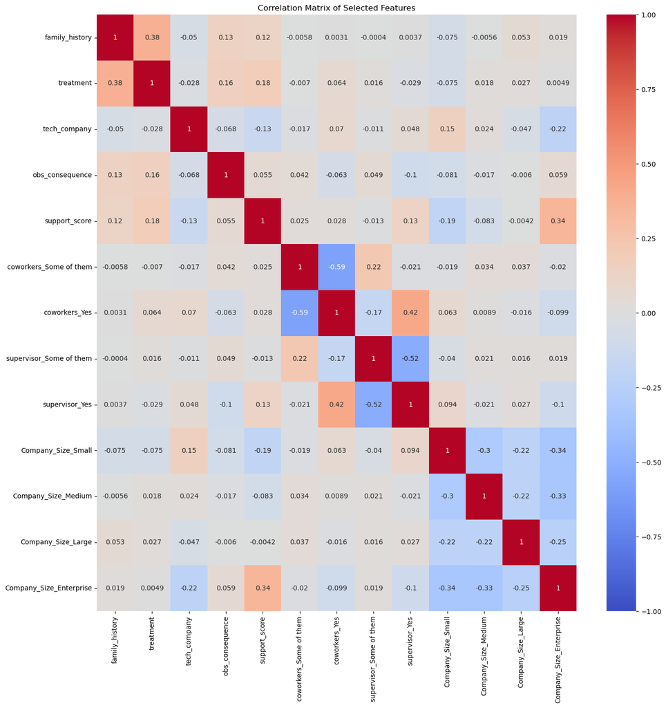

```python
corr2 = df2.corr()

plt.figure(figsize=(16,16))
sns.heatmap(corr2, annot=True, cmap="coolwarm", vmin=-1, vmax=1)
plt.title("Correlation Matrix of Selected Features")
plt.show()
```

```python
#correlation_matrix = new_df.corr()

#plt.figure(figsize=(16,16))
#sns.heatmap(correlation_matrix, annot=True, cmap="coolwarm", vmin=-1, vmax=1, fmt="o.2f")
#plt.title("Correlation Matrix")
#plt.show()
```

### Modeling:

### 1. Random Forest

```python
from sklearn.ensemble import RandomForestClassifier
from sklearn.model_selection import train_test_split
#from sklearn.preprocessing import StandardScaler

X_train, X_test, y_train, y_test = train_test_split(new_df, Y, test_size = 0.2, random_state=42)

rf_model = RandomForestClassifier(random_state=42)
rf_model.fit(X_train, y_train)

feature_importances = pd.Series(rf_model.feature_importances_, index=new_df.columns).sort_values(ascending=False)

print('Top features contributing to mental health:')
print(feature_importances.head(10))
```

```
Top features contributing to mental health:
family_history              0.115861
support_score               0.055555
coworkers_Some of them      0.041019
phys_health_interview_No    0.038674
benefits_Yes                0.038310
supervisor_Some of them     0.033384
leave_Somewhat easy         0.033153
seek_help_No                0.032372
benefits_No                 0.031904
Company_Size_Medium         0.031653
dtype: float64
```

```python
X = df2.drop('treatment', axis=1)
```

```python
X_train, X_test, y_train, y_test = train_test_split(X, Y, test_size = 0.2, random_state=42)

rf_model2 = RandomForestClassifier(random_state=42)
rf_model2.fit(X_train, y_train)

feature_importances = pd.Series(rf_model2.feature_importances_, index=X.columns).sort_values(ascending=False)

print('Top features contributing to mental health:')
print(feature_importances.head(10))
```

```
Top features contributing to mental health:
support_score              0.253504
family_history             0.222104
tech_company               0.069199
obs_consequence            0.068569
coworkers_Some of them     0.068150
Company_Size_Enterprise    0.054810
supervisor_Yes             0.052932
supervisor_Some of them    0.048850
Company_Size_Medium        0.047563
Company_Size_Large         0.041257
dtype: float64
```